# Premier League

Jaume Amorós

January 2020

# Pràctica 2: Neteja i anàlisi de dades

## Introducció

En aquesta pràctica s’analitzarà les dades disponibles a [Kaggle](https://www.kaggle.com) sobre [resultats de partits de la Premier League](https://www.kaggle.com/zaeemnalla/premier-league) de futbol anglesa de les temporades des de 06-07 a 17-18.

### Objectiu

L’objectiu d’aquesta pràctica serà fer una anàlisi sobre la possible relació entre el variables del conjunt de dades. Inicialment es farà una exploració i neteja de les dades. A continuació es realitzaran 3 anàlisis esta´distics per respondre a aquestes preguntes:

- *El nivell de l’equip de futbol està relacionat amb el nombre de targetes que rep?*
- *El nombre de xuts estan relacionats amb nombre de gols que acaben fent els equips?*
- *El nombre de faltes comeses està relacionat amb el nombre de targetes rebudes?*

## Descripció del conjunt de dades

Les dades estan organitzades en dos fitxers csv. El primer, results.csv, d’ells conté el resultat de cada partit sense mostrar estadsítiques del joc. Cada register correspona a un partit. Les variables que hi ha recollides són:

- **home_team**: nom de l’equip que juga com a local.
- **away_team**: nom de l’equip que juga coma visitant.
- **home_goals**: nombre de gols fets per l’equip local.
- **away_goals**: nombre de gols fets per l’equip visitnat.
- **result**: resultat del partit (categoritzat com a H: victoria per l’equip local, A: victoria per l’equip visitant, D: empat).
- **season**: temporada, expressat numericament en XXXX-XXXX.

El segon fitxer es diu stats.csv i conté els estadístiques dels equips a cada temporada. Cada registre correspon a un equip i temporada. D’entre les variables que hi ha tenim:

- **team**: nom de l’equip.
- **season**: temporada, expressat numericament en XXXX-XXXX.
- **goals**: nombre de gols anotats per l’equip durant la temporada.
- **total_yel_card**: nombre total de targetes grogues amb que ha estat amonestat l’equip durant la temporada.
- **total_red_card**: nombre total de targetes vermelles amb que ha estat amonestat l’equip durant la temporada.
- **total_scoring_att**: nombre total de xuts fets per l’equip durant la temporada.
- **total_tackle**: nombre total de faltes/entrades comeses.

## Preparació de les dades

### Importació de dades

Els fitxers estan disponibles per ser descarregats a l’enllça especificat a la descripció. En aquest primer pas importem les dades en R.

```r
results <- read.csv("data/results.csv", stringsAsFactors = FALSE, header = TRUE)
stats   <- read.csv("data/stats.csv", stringsAsFactors = FALSE, header = TRUE)

# Seleccionem les variables d'interès del dataset stats:
stats   <- stats[,  c('team', 'season', 'goals', 'total_yel_card', 'total_red_card', 'total_scoring_att', 'ontarget_scoring_att', 'total_tackle')]

# Mirem el nombre de registres i columnes de cada conjunt de dades
dim(results)
```

```
## [1] 4560    6
```

```r
dim(stats)
```

```
## [1] 240   8
```

Comprovem l’estructura de les nostres dades:

```r
str(results)
```

```
## 'data.frame':    4560 obs. of  6 variables:
##  $ home_team : chr  "Sheffield United" "Arsenal" "Everton" "Newcastle United" ...
##  $ away_team : chr  "Liverpool" "Aston Villa" "Watford" "Wigan Athletic" ...
##  $ home_goals: num  1 1 2 2 3 3 3 2 5 3 ...
##  $ away_goals: num  1 1 1 1 0 2 1 0 1 0 ...
##  $ result    : chr  "D" "D" "H" "H" ...
##  $ season    : chr  "2006-2007" "2006-2007" "2006-2007" "2006-2007" ...
```

```r
str(stats)
```

```
## 'data.frame':    240 obs. of  8 variables:
##  $ team                : chr  "Manchester United" "Chelsea" "Liverpool" "Arsenal" ...
##  $ season              : chr  "2006-2007" "2006-2007" "2006-2007" "2006-2007" ...
##  $ goals               : num  83 64 57 63 57 47 52 52 52 45 ...
##  $ total_yel_card      : num  60 62 44 59 48 84 38 77 65 48 ...
##  $ total_red_card      : num  1 4 0 3 3 4 3 6 2 1 ...
##  $ total_scoring_att   : num  698 636 668 638 520 404 419 478 465 525 ...
##  $ ontarget_scoring_att: num  256 216 214 226 184 120 132 155 153 186 ...
##  $ total_tackle        : num  890 982 969 998 995 811 855 864 860 948 ...
```

### Evaluació de valors perduts i allunyats

#### Valors perduts

Evaluem si hi ha valors perduts en alguna de les nostres variables d’interès. Aprofitem la funció que recorre cada columna del dataset indicat i avalua la funció indicada. Comptem el nombre de casos en que hi ha un missing (NA) a cada variable.

```r
sapply(results, function(x) sum(is.na(x)))
```

```
##  home_team  away_team home_goals away_goals     result     season
##          0          0          0          0          0          0
```

```r
sapply(stats, function(x) sum(is.na(x)))
```

```
##                 team               season                goals
##                    0                    0                    0
##       total_yel_card       total_red_card    total_scoring_att
##                    0                    0                    0
## ontarget_scoring_att         total_tackle
##                    0                    0
```

Com era d’esperar no hi ha cap valor perdut. Son dades recents i fàcliment completables ja que es poden consultar.

#### Valors extrems

Explorem si existeixen valors extrems en les nostres dades que en poguessin condicionar els analisis. Per a fer-ho, aprofitarem el boxplot. Al generar un boxplot, R, ens guarda elsvalors descriptius calculats. En podem consutlar si apareixen valors anormalment allunyats en les variables quantitatives d’interès:

```r
boxplot.stats(stats$goals)$out
```

```
## [1] 103  93 102 101 106
```

```r
boxplot.stats(stats$total_yel_card)$out
```

```
## [1] 94
```

```r
boxplot.stats(stats$total_scoring_att)$out
```

```
## [1] 797 834
```

```r
boxplot.stats(stats$total_tackle)$out
```

```
## [1] 1089
```

### Calcul de noves variables

Per l’analisis que ens interesa, calcularem el nombre de punts obtinguts per cada equip cada temporada. D’aquesta manera, podrem calcular la seva posició final a la classificació d’aquell any. Amb la classificació crearem una nova variable que ens permetrà distingir a cada temporada els 5 millors equips i els 5 pitjors.

```r
# Calculem les variables de punts
results$home_points <- ifelse(results$result == "H", 3,
                              ifelse(results$result == "A", 0, 1))
results$away_points <- ifelse(results$result == "A", 3,
                              ifelse(results$result == "H", 0, 1))

# Unim tots els punts en un únic conjunt de dades
home_results <- results[, c("home_team", "season", "home_points")]
away_results <- results[, c("away_team", "season", "away_points")]
noms_col <- c("team", "season", "points")
colnames(home_results) <- noms_col
colnames(away_results) <- noms_col
points <- rbind(home_results, away_results)

# Calculem la classificació de cada temporada a partir dels punts
classif <- points %>% group_by(team, season) %>% summarise(Points = sum(points)) %>% ungroup()
classif <- classif[order(classif$season, -classif$Points), ]
classif$class <- rep(1:20, 12)

# Calculem els millors i els pitjors equips de cada temporada
classif$top5bot5 <- ifelse(classif$class <= 5, "TOP5",
                           ifelse(classif$class >= 16, "BOT5", NA))

# Afegim el classificador de millors i pitjors equips de cada temporada a les dades d'estadístiques.
stats <- left_join(stats, classif[, c("team", "season", "top5bot5")])

# Nombre total de targetes rebudes
stats$total_card <- stats$total_red_card + stats$total_yel_card
```

## Anàlisi de dades

### 1. Relació entre nivell de l’equip i nombre de targetes

El nombre de targetes rebudes pot ser diferent en funció del nivell de l’equip. Ens plantegem les hipotesis:

- *H0 nula: el nivell de l’equip no afecta al nombre de targetes rebudes al llarg de la temporada.*
- *H1 alternativa: el nivell de l’equip i el nombre de tagetes rebudes durant la temporada estan relacionts.*

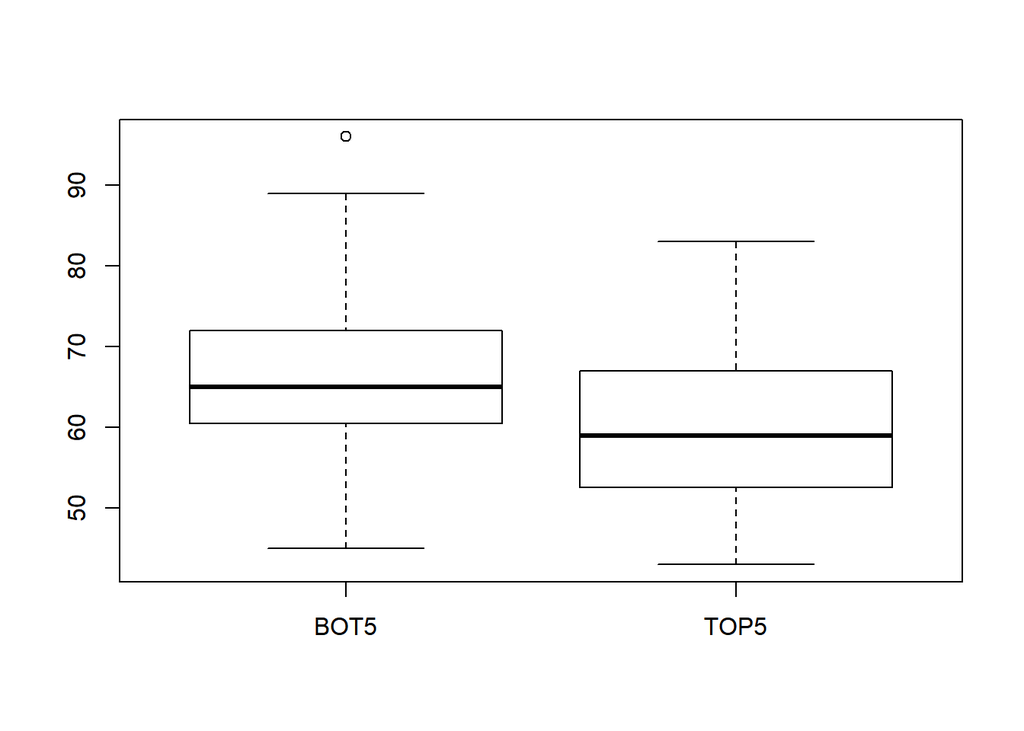

```r
# Distribuió de la variable
boxplot(total_card ~ top5bot5, stats)
```

```r
# Test de normalitat
shapiro.test(stats[which(stats$top5bot5 == 'TOP5'),  "total_card"])
```

```
##
##  Shapiro-Wilk normality test
##
## data:  stats[which(stats$top5bot5 == "TOP5"), "total_card"]
## W = 0.97562, p-value = 0.2718
```

```r
shapiro.test(stats[which(stats$top5bot5 == 'BOT5'),  "total_card"])
```

```
##
##  Shapiro-Wilk normality test
##
## data:  stats[which(stats$top5bot5 == "BOT5"), "total_card"]
## W = 0.97458, p-value = 0.2429
```

```r
# Test de homogenietat de variances
leveneTest(stats$total_card, stats$top5bot5)
```

|  | Df | F value | Pr(>F) |
| --- | --- | --- | --- |
| group | 1 | 0.4656899 | 0.4963142 |
|  | 118 | NA | NA |

Res indica que no es compleixien els suposits de normalitat ni homogeneitat de variances. Procedim amb l’anàlisi de comparació de mitjanes:

```r
t.test(total_card ~ top5bot5, stats)
```

```
##
##  Welch Two Sample t-test
##
## data:  total_card by top5bot5
## t = 3.7088, df = 118, p-value = 0.0003189
## alternative hypothesis: true difference in means is not equal to 0
## 95 percent confidence interval:
##   3.075974 10.124026
## sample estimates:
## mean in group BOT5 mean in group TOP5
##           66.23333           59.63333
```

#### Resultats 1

Els resultats mostren que la mitjana de targetes rebudes pels equips TOP es menor que les rebudes pels equips BOT. Els equips TOP reben de mitjana 59,6 targetes per temporada, mentre que els equips BOT en reben 66,2. Aquesta diferencia de 6,6 targetes és estadísticament significativa (t=3,71 p=0,0003). Amb una confiança del 95% aquest efecte estarà entre 3,1 i 10,1 targetes.

### 2. Nombre de xuts i nombre de gols

Avaluem si el nombre de gols que es marquen està relacioat amb el nombre de xuts a porta que es fan. Ens plantegem les hipotesis:

- *H0 nula: el nombre de xuts a porta no afecta el nombre de gols marcats.*
- *H1 alternativa: el nombre de xuts a porta estàrelacionat amb el nombre de gols marcats.*

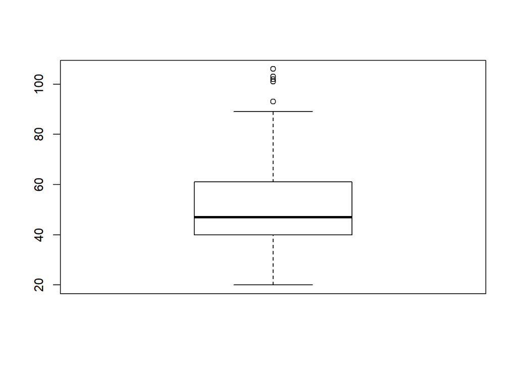

```r
# Distribuió de les variable
boxplot(stats$goals)
```

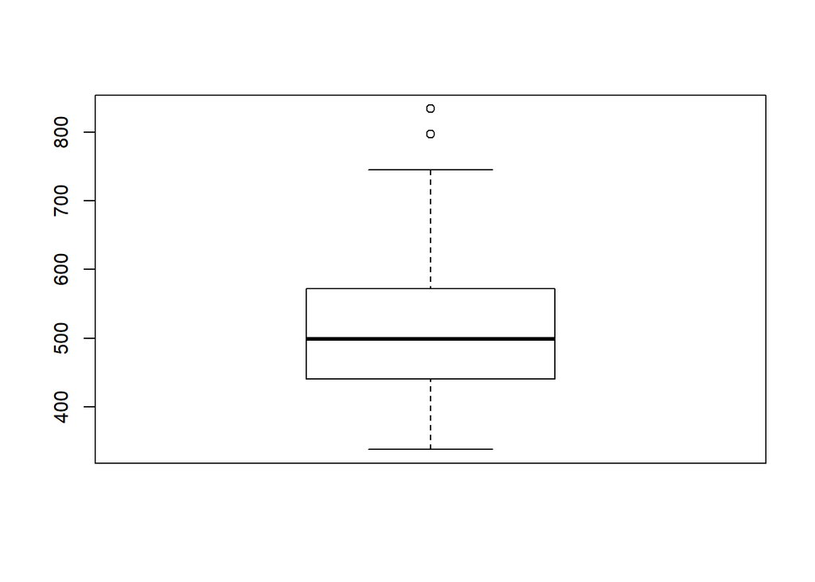

```r
boxplot(stats$total_scoring_att)
```

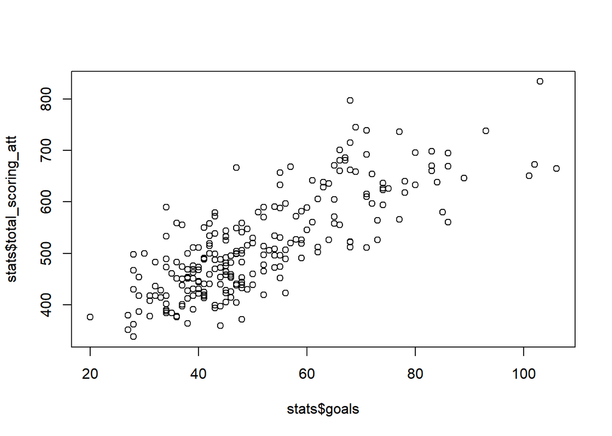

```r
plot(stats$goals, stats$total_scoring_att)
```

```r
# Test de normalitat
shapiro.test(stats$goals)
```

```
##
##  Shapiro-Wilk normality test
##
## data:  stats$goals
## W = 0.93322, p-value = 5.722e-09
```

```r
shapiro.test(stats$total_scoring_att)
```

```
##
##  Shapiro-Wilk normality test
##
## data:  stats$total_scoring_att
## W = 0.95956, p-value = 2.772e-06
```

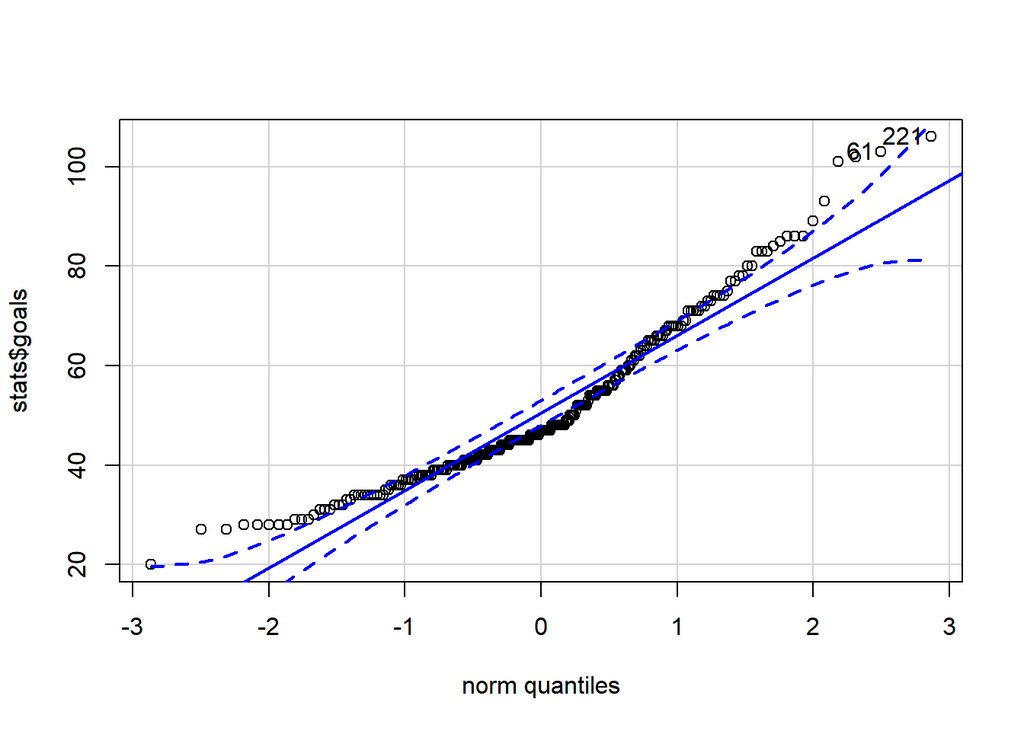

```
## [1] 221  61
```

```r
qqPlot(stats$goals)
```

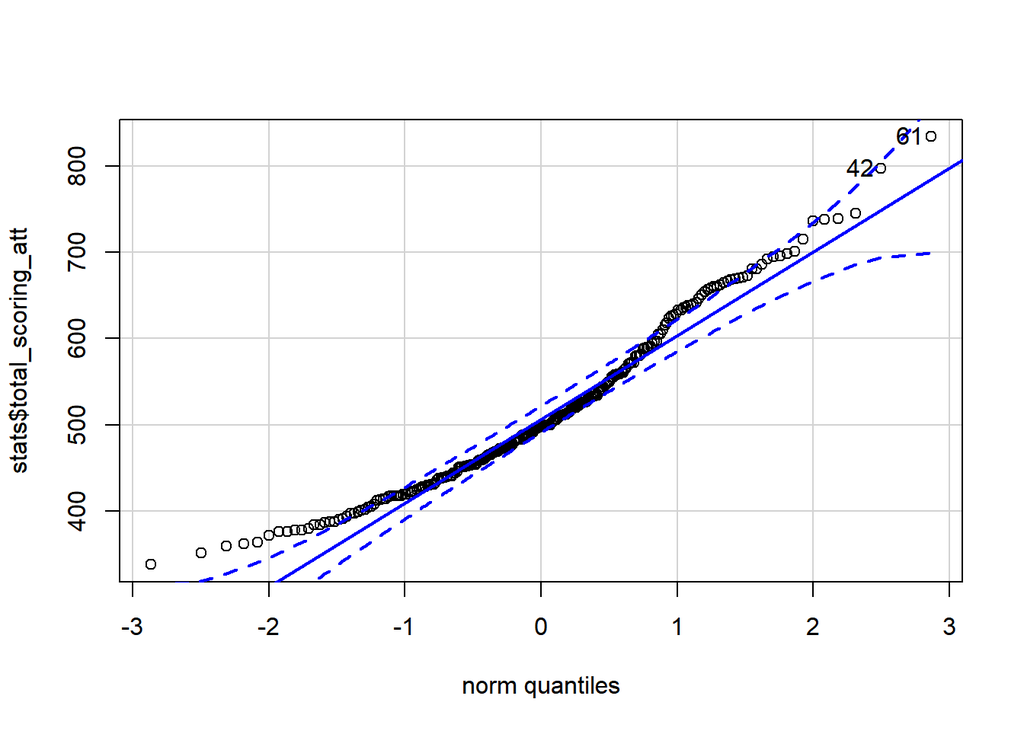

```
## [1] 61 42
```

```r
qqPlot(stats$total_scoring_att)
```

El gràfic de dispersió mostra una relació força evident entre aquestes dues variables. Però les proves de normalitat, semblen indicar que hi ha cert biaix i que no podem considerar que les distribucions de les variables *goal* i *total_scoring_att* siguin normals.

```r
cor(stats$goals, stats$total_scoring_att)
```

```
## [1] 0.7880625
```

```r
model <- glm(goals ~ total_scoring_att, data=stats)
summary(model)
```

```
##
## Call:
## glm(formula = goals ~ total_scoring_att, data = stats)
##
## Deviance Residuals:
##     Min       1Q   Median       3Q      Max
## -27.142   -6.597   -0.981    6.423   34.880
##
## Coefficients:
##                     Estimate Std. Error t value Pr(>|t|)
## (Intercept)       -17.353722   3.523793  -4.925 1.58e-06 ***
## total_scoring_att   0.133043   0.006737  19.749  < 2e-16 ***
## ---
## Signif. codes:  0 '***' 0.001 '**' 0.01 '*' 0.05 '.' 0.1 ' ' 1
##
## (Dispersion parameter for gaussian family taken to be 99.91432)
##
##     Null deviance: 62750  on 239  degrees of freedom
## Residual deviance: 23780  on 238  degrees of freedom
## AIC: 1790.1
##
## Number of Fisher Scoring iterations: 2
```

#### Resultats 2

De tota manera, observem que la seva relació és important: 0,788. Un model lineal ens indica que per a cada xut a porta, es marquen 0,13 gols més. Aquest efecte és estadísticament molt significatiu (p<0,001). El nombre de xuts a fer, per marcar un gol es de 8 ( [NNT](https://en.wikipedia.org/wiki/Number_needed_to_treat)).

### 3. Nombre de faltes comeses i targetes

Avalume si existeix relació entre el nombre de faltes comeses i el nombre de targetes rebudes per un equip. Ens plantegem les hipotesis:

- *H0 nula: el nombre de targetes rebudes no està relacionat amb el nombre de faltes rebudes.*
- *H1 alternativa: el nombre de targetes rebudes està relacionat amb el nombre de faltes rebudes.*

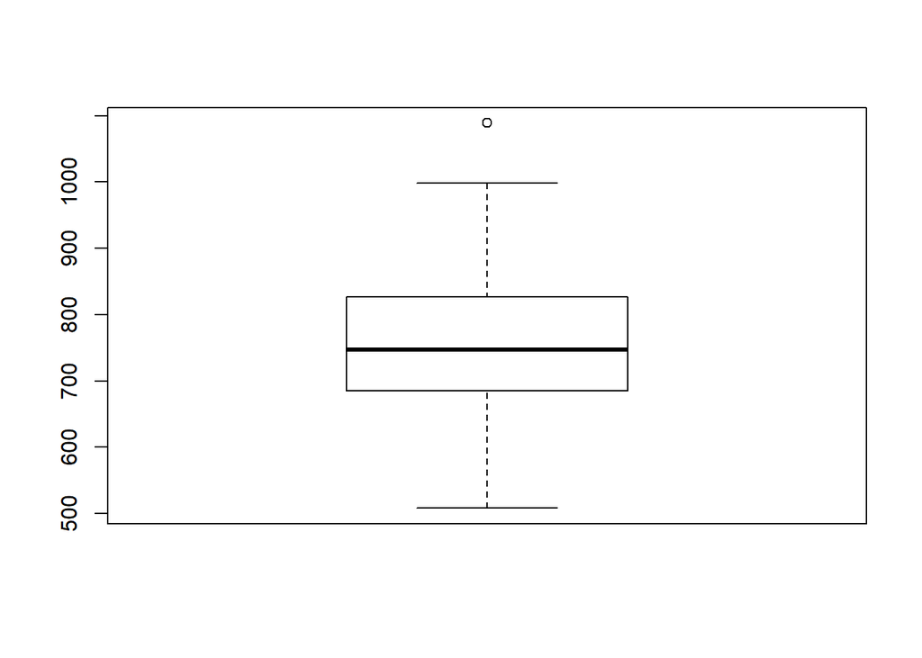

```r
# Distribuió de les variable
boxplot(stats$total_tackle)
```

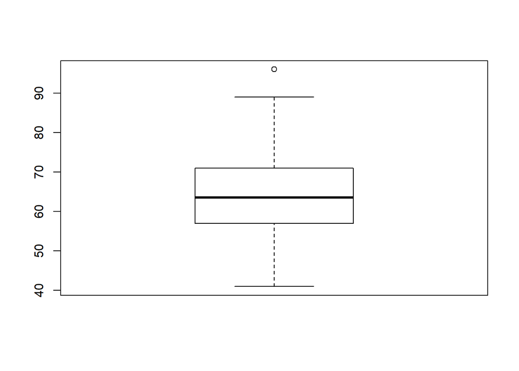

```r
boxplot(stats$total_card)
```

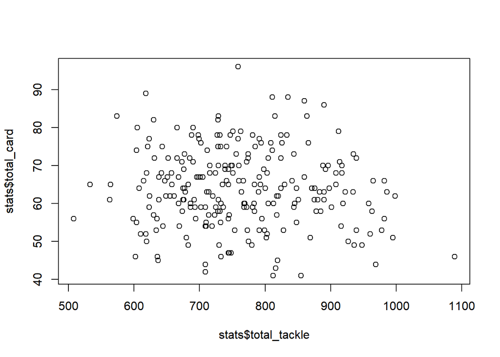

```r
plot(stats$total_tackle, stats$total_card)
```

```r
# Test de normalitat
shapiro.test(stats$total_card)
```

```
##
##  Shapiro-Wilk normality test
##
## data:  stats$total_card
## W = 0.99419, p-value = 0.4852
```

```r
shapiro.test(stats$total_tackle)
```

```
##
##  Shapiro-Wilk normality test
##
## data:  stats$total_tackle
## W = 0.9846, p-value = 0.01068
```

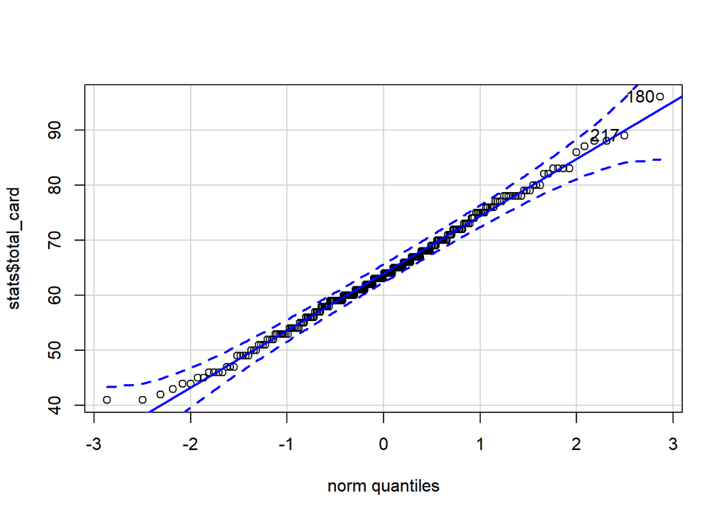

```
## [1] 180 217
```

```r
qqPlot(stats$total_card)
```

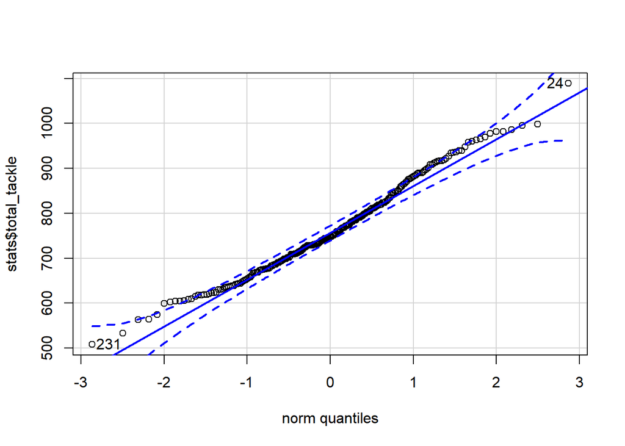

```
## [1]  24 231
```

```r
qqPlot(stats$total_tackle)
```

El gràfic de dispersió no sembla mostrar cap rleació entre el nombre de targetes i el nombre de faltes. L’exploració visual de la normalitat sembla indicar normalitat, però les prova de Shapiro-Wilk es significativa per al nombre de faltes comeses. En el q-q plot podem observar que probablment es degui als valors allunyats.

```r
cor(stats$total_card, stats$total_tackle)
```

```
## [1] -0.07064915
```

```r
model <- glm(total_card ~ total_tackle, data=stats)
summary(model)
```

```
##
## Call:
## glm(formula = total_card ~ total_tackle, data = stats)
##
## Deviance Residuals:
##     Min       1Q   Median       3Q      Max
## -22.595   -6.681   -0.202    7.023   32.037
##
## Coefficients:
##               Estimate Std. Error t value Pr(>|t|)
## (Intercept)  69.237357   4.891973  14.153   <2e-16 ***
## total_tackle -0.006949   0.006359  -1.093    0.276
## ---
## Signif. codes:  0 '***' 0.001 '**' 0.01 '*' 0.05 '.' 0.1 ' ' 1
##
## (Dispersion parameter for gaussian family taken to be 105.9608)
##
##     Null deviance: 25345  on 239  degrees of freedom
## Residual deviance: 25219  on 238  degrees of freedom
## AIC: 1804.2
##
## Number of Fisher Scoring iterations: 2
```

#### Resultats 3

Tal com podiem preveure amb el gràfic de dispersió inicial. No existeix relació entre el nombre de faltes comeses i el nombre de targetes rebudes per un equp al llarg de la temporada.

## Conclusions

Pel que hem pogut veure, els millors equips reben menys targetes que els equips que acaben últims. La relació de fet seria a l’inrevés, ja que les targetes es succeeixen abans que la classificació. Rebre més targetes, o jugar de manera que es rebn més targerets, acaba situant l’equip en pitjor classificació.

Els equips més ofensius que són capaços de fer més xuts a porta són els que marquen més gols. Aquesta relació sembla força evident, però es podria pensar que hi ha equips amb devanteres molt decisives o porters excepcionals. No hem trobat evidencies de que això sigui així a la Premier League. Si es xuta es marca.

No s’ha trobat relació entre el nombre de targetes rebudes i el nombre de faltes comeses. Les targetes rebudes per tant, no venen determinades pel nombre de faltes que es facin. Un estil de joc més destructiu no necessariament està penalitzat amb targetes. Fins i tot els equips que tendeixen a fet menys faltes, també es poden trobar amb necessitat de fer faltes compromeses que siguin penades amb targeta.

```r
# Exportem les dades finals
write.csv(stats, "data/stats_final.csv")
```